# StreamSphere Analytics: OTT Content & User Engagement Analysis

### Business Problem

OTT platforms such as Netflix, Amazon Prime, and Disney+ host thousands of movies and TV shows across multiple genres, countries, and content categories. With a growing content library, it becomes challenging to understand what type of content attracts users, which genres are most popular, how viewing preferences vary across demographics, and what factors influence user engagement.

Without data-driven insights, OTT platforms may struggle to:

- Recommend relevant content to users.
- Invest in high-performing genres and content categories.
- Understand user viewing behavior.
- Improve subscriber retention and engagement.

### Project Objective

*The objective of this project is to build a relational database and analytics solution that helps an OTT platform analyze its content library and user engagement patterns.*

The project will:

### Scope of the Project

- Content Analysis
- Movies vs TV Shows distribution
- Genre popularity
- Country-wise content production
- Content release trends over time
- Content ratings analysis

### Project Architecture

```
                                                          Data Collection

                                                                ↓
                                                           Data Cleaning

                                                                ↓
                                                        Normalization of Data

                                                                ↓
                                                   Database Design and Implentation

                                                                ↓
                                                       SQL Quries and Analysis

                                                                ↓
                                                   Python Visualization of SQL Results

                                                                ↓
                                                            Conclusion
```

#### Data Understanding and Cleaning

```python
import pandas as pd

df = pd.read_csv(r"C:\Users\Admin\Downloads\archive\netflix_titles.csv")

df.shape
```

```
(8807, 12)
```

```python
df.head()
```

|  | show_id | type | title | director | cast | country | date_added | release_year | rating | duration | listed_in | description |
| --- | --- | --- | --- | --- | --- | --- | --- | --- | --- | --- | --- | --- |
| 0 | s1 | Movie | Dick Johnson Is Dead | Kirsten Johnson | NaN | United States | September 25, 2021 | 2020 | PG-13 | 90 min | Documentaries | As her father nears the end of his life, filmm... |
| 1 | s2 | TV Show | Blood & Water | NaN | Ama Qamata, Khosi Ngema, Gail Mabalane, Thaban... | South Africa | September 24, 2021 | 2021 | TV-MA | 2 Seasons | International TV Shows, TV Dramas, TV Mysteries | After crossing paths at a party, a Cape Town t... |
| 2 | s3 | TV Show | Ganglands | Julien Leclercq | Sami Bouajila, Tracy Gotoas, Samuel Jouy, Nabi... | NaN | September 24, 2021 | 2021 | TV-MA | 1 Season | Crime TV Shows, International TV Shows, TV Act... | To protect his family from a powerful drug lor... |
| 3 | s4 | TV Show | Jailbirds New Orleans | NaN | NaN | NaN | September 24, 2021 | 2021 | TV-MA | 1 Season | Docuseries, Reality TV | Feuds, flirtations and toilet talk go down amo... |
| 4 | s5 | TV Show | Kota Factory | NaN | Mayur More, Jitendra Kumar, Ranjan Raj, Alam K... | India | September 24, 2021 | 2021 | TV-MA | 2 Seasons | International TV Shows, Romantic TV Shows, TV ... | In a city of coaching centers known to train I... |

```python
df.info()
```

```
<class 'pandas.DataFrame'>
RangeIndex: 8807 entries, 0 to 8806
Data columns (total 12 columns):
 #   Column        Non-Null Count  Dtype
---  ------        --------------  -----
 0   show_id       8807 non-null   str
 1   type          8807 non-null   str
 2   title         8807 non-null   str
 3   director      6173 non-null   str
 4   cast          7982 non-null   str
 5   country       7976 non-null   str
 6   date_added    8797 non-null   str
 7   release_year  8807 non-null   int64
 8   rating        8803 non-null   str
 9   duration      8804 non-null   str
 10  listed_in     8807 non-null   str
 11  description   8807 non-null   str
dtypes: int64(1), str(11)
memory usage: 825.8 KB
```

```python
df.describe()
```

|  | release_year |
| --- | --- |
| count | 8807.000000 |
| mean | 2014.180198 |
| std | 8.819312 |
| min | 1925.000000 |
| 25% | 2013.000000 |
| 50% | 2017.000000 |
| 75% | 2019.000000 |
| max | 2021.000000 |

```python
df.isnull().sum().sort_values(ascending=False)
```

```
director        2634
country          831
cast             825
date_added        10
rating             4
duration           3
show_id            0
type               0
title              0
release_year       0
listed_in          0
description        0
dtype: int64
```

```python
df['director'] = df['director'].fillna('Unknown')
```

```python
df['cast'] = df['cast'].fillna('Unknown')
```

```python
df['country'] = df['country'].fillna('Unknown')
```

```python
df['rating'] = df['rating'].fillna(df['rating'].mode()[0])
```

```python
df.head()
```

|  | show_id | type | title | director | cast | country | date_added | release_year | rating | duration | listed_in | description |
| --- | --- | --- | --- | --- | --- | --- | --- | --- | --- | --- | --- | --- |
| 0 | s1 | Movie | Dick Johnson Is Dead | Kirsten Johnson | Unknown | United States | September 25, 2021 | 2020 | PG-13 | 90 min | Documentaries | As her father nears the end of his life, filmm... |
| 1 | s2 | TV Show | Blood & Water | Unknown | Ama Qamata, Khosi Ngema, Gail Mabalane, Thaban... | South Africa | September 24, 2021 | 2021 | TV-MA | 2 Seasons | International TV Shows, TV Dramas, TV Mysteries | After crossing paths at a party, a Cape Town t... |
| 2 | s3 | TV Show | Ganglands | Julien Leclercq | Sami Bouajila, Tracy Gotoas, Samuel Jouy, Nabi... | Unknown | September 24, 2021 | 2021 | TV-MA | 1 Season | Crime TV Shows, International TV Shows, TV Act... | To protect his family from a powerful drug lor... |
| 3 | s4 | TV Show | Jailbirds New Orleans | Unknown | Unknown | Unknown | September 24, 2021 | 2021 | TV-MA | 1 Season | Docuseries, Reality TV | Feuds, flirtations and toilet talk go down amo... |
| 4 | s5 | TV Show | Kota Factory | Unknown | Mayur More, Jitendra Kumar, Ranjan Raj, Alam K... | India | September 24, 2021 | 2021 | TV-MA | 2 Seasons | International TV Shows, Romantic TV Shows, TV ... | In a city of coaching centers known to train I... |

```python
df.duplicated().sum()
```

```
np.int64(0)
```

```python
df = df.drop_duplicates()
```

```python
df['date_added'] = pd.to_datetime(
    df['date_added'],
    errors='coerce'
)
```

```python
df['month_added'] = df['date_added'].dt.month
```

```python
df['year_added'] = df['date_added'].dt.year
```

```python
text_cols = [
    'director',
    'cast',
    'country',
    'listed_in'
]

for col in text_cols:
    df[col] = df[col].str.strip()
```

```python
df['type'].value_counts()
```

```
type
Movie      6131
TV Show    2676
Name: count, dtype: int64
```

```python
df['rating'].value_counts()
```

```
rating
TV-MA       3211
TV-14       2160
TV-PG        863
R            799
PG-13        490
TV-Y7        334
TV-Y         307
PG           287
TV-G         220
NR            80
G             41
TV-Y7-FV       6
NC-17          3
UR             3
74 min         1
84 min         1
66 min         1
Name: count, dtype: int64
```

```python
df = df[~df['rating'].str.contains('min', na=False)]
```

```python
df['rating'].value_counts()
```

```
rating
TV-MA       3211
TV-14       2160
TV-PG        863
R            799
PG-13        490
TV-Y7        334
TV-Y         307
PG           287
TV-G         220
NR            80
G             41
TV-Y7-FV       6
NC-17          3
UR             3
Name: count, dtype: int64
```

```python
df['country'].nunique()
```

```
749
```

```python
df['listed_in'].nunique()
```

```
514
```

```python
df.to_csv("netflix_cleaned.csv",index=False)
```

```python
df.to_csv(
    r"C:\Users\Admin\Downloads\archive\netflix_cleaned.csv",
    index=False
)
```

```python
import pandas as pd
df=pd.read_csv(r"C:\Users\Admin\Downloads\archive\netflix_cleaned1.csv")
```

```python
df.head()
```

|  | show_id | type | title | director | cast | country | date_added | release_year | rating | duration | listed_in | description | month_added | year_added |
| --- | --- | --- | --- | --- | --- | --- | --- | --- | --- | --- | --- | --- | --- | --- |
| 0 | s1 | Movie | Dick Johnson Is Dead | Kirsten Johnson | Unknown | United States | 25-09-2021 | 2020 | PG-13 | 90 min | Documentaries | As her father nears the end of his life, filmm... | 9.0 | 2021.0 |
| 1 | s2 | TV Show | Blood & Water | Unknown | Ama Qamata, Khosi Ngema, Gail Mabalane, Thaban... | South Africa | 24-09-2021 | 2021 | TV-MA | 2 Seasons | International TV Shows, TV Dramas, TV Mysteries | After crossing paths at a party, a Cape Town t... | 9.0 | 2021.0 |
| 2 | s3 | TV Show | Ganglands | Julien Leclercq | Sami Bouajila, Tracy Gotoas, Samuel Jouy, Nabi... | Unknown | 24-09-2021 | 2021 | TV-MA | 1 Season | Crime TV Shows, International TV Shows, TV Act... | To protect his family from a powerful drug lor... | 9.0 | 2021.0 |
| 3 | s4 | TV Show | Jailbirds New Orleans | Unknown | Unknown | Unknown | 24-09-2021 | 2021 | TV-MA | 1 Season | Docuseries, Reality TV | Feuds, flirtations and toilet talk go down amo... | 9.0 | 2021.0 |
| 4 | s5 | TV Show | Kota Factory | Unknown | Mayur More, Jitendra Kumar, Ranjan Raj, Alam K... | India | 24-09-2021 | 2021 | TV-MA | 2 Seasons | International TV Shows, Romantic TV Shows, TV ... | In a city of coaching centers known to train I... | 9.0 | 2021.0 |

```python
df.isnull().sum()
```

```
show_id         0
type            0
title           0
director        0
cast            0
country         0
date_added      0
release_year    0
rating          0
duration        0
listed_in       0
description     0
month_added     0
year_added      0
dtype: int64
```

```python
df = df.dropna(subset=['date_added'])
```

```python
df.isnull().sum()
```

```
show_id         0
type            0
title           0
director        0
cast            0
country         0
date_added      0
release_year    0
rating          0
duration        0
listed_in       0
description     0
month_added     0
year_added      0
dtype: int64
```

```python
df.to_csv(
    r"C:\Users\Admin\Downloads\archive\netflix_cleaned1.csv",
    index=False
)
```

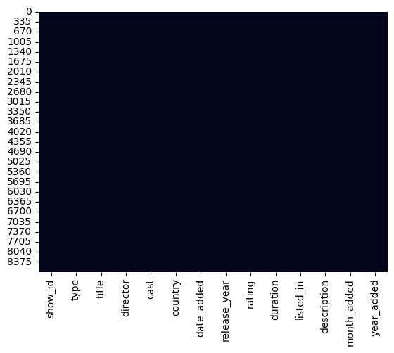

```python
import seaborn as sns
import matplotlib.pyplot as plt

sns.heatmap(df.isnull(), cbar=False)
plt.show()
```

```python
for col in df.columns:
    print(col, ":", df[col].nunique())
```

```
show_id : 8706
type : 2
title : 8703
director : 4524
cast : 7605
country : 746
date_added : 1698
release_year : 74
rating : 14
duration : 220
listed_in : 509
description : 8675
month_added : 12
year_added : 14
```

```python
df['type'].value_counts()
```

```
type
Movie      6128
TV Show    2578
Name: count, dtype: int64
```

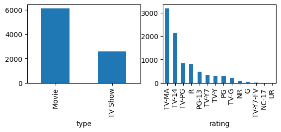

```python
plt.figure(figsize=(10,7))
plt.subplot(331)
df['type'].value_counts().plot(kind='bar')

plt.subplot(332)
df['rating'].value_counts().plot(kind='bar')
plt.show()
plt.tight_layout()
```

```python
df['country'].nunique()
```

```
746
```

```python
df["country"].value_counts().head(20)
```

```
country
United States                    2775
India                             971
Unknown                           827
United Kingdom                    403
Japan                             241
South Korea                       195
Canada                            173
Spain                             141
France                            122
Mexico                            110
Egypt                             106
Turkey                            105
Nigeria                            95
Australia                          85
Taiwan                             81
Indonesia                          79
Brazil                             77
Philippines                        75
United Kingdom, United States      74
United States, Canada              73
Name: count, dtype: int64
```

```python
df['listed_in'].nunique()
```

```
509
```

```python
df['listed_in'].value_counts().head(20)
```

```
listed_in
Dramas, International Movies                         362
Documentaries                                        359
Stand-Up Comedy                                      334
Comedies, Dramas, International Movies               274
Dramas, Independent Movies, International Movies     252
Children & Family Movies                             215
Kids' TV                                             212
Children & Family Movies, Comedies                   201
Documentaries, International Movies                  186
Dramas, International Movies, Romantic Movies        180
Comedies, International Movies                       176
Comedies, International Movies, Romantic Movies      152
Dramas                                               138
Dramas, International Movies, Thrillers              134
Action & Adventure, Dramas, International Movies     132
Action & Adventure                                   128
International TV Shows, TV Dramas                    121
Comedies, Dramas, Independent Movies                 116
Comedies                                             110
Crime TV Shows, International TV Shows, TV Dramas    108
Name: count, dtype: int64
```

```python
df['director'].nunique()
```

```
4524
```

```python
df['director'].value_counts().head(20)
```

```
director
Unknown                   2541
Rajiv Chilaka               19
Raúl Campos, Jan Suter      18
Suhas Kadav                 16
Marcus Raboy                16
Jay Karas                   14
Cathy Garcia-Molina         13
Youssef Chahine             12
Martin Scorsese             12
Jay Chapman                 12
Steven Spielberg            11
Don Michael Paul            10
David Dhawan                 9
Quentin Tarantino            8
Robert Rodriguez             8
Yılmaz Erdoğan               8
Hakan Algül                  8
Fernando Ayllón              8
Troy Miller                  8
Kunle Afolayan               8
Name: count, dtype: int64
```

```python
df['cast'].dropna().sample(10)
```

```
515     Saoirse-Monica Jackson, Nicola Coughlan, Louis...
7301    Lily Collins, Sam Claflin, Christian Cooke, Ja...
1553         David Spade, London Hughes, Fortune Feimster
4250                                              Unknown
8071    Tony Goldwyn, Minnie Driver, Glenn Close, Bria...
6864                Guy Martin, Kevin Stone, Shaun Dooley
6109                                              Unknown
1802    Elizabeth Bogush, Brad Schmidt, Sarah Lind, Ed...
1218    Jennifer Garner, Edgar Ramírez, Jenna Ortega, ...
5927    James Cameron, Michael deGruy, Sylvia Earle, B...
Name: cast, dtype: str
```

```python
df['release_year'].value_counts().sort_index()
```

```
release_year
1925       1
1942       2
1943       3
1944       3
1945       4
        ...
2017    1015
2018    1140
2019    1030
2020     953
2021     592
Name: count, Length: 74, dtype: int64
```

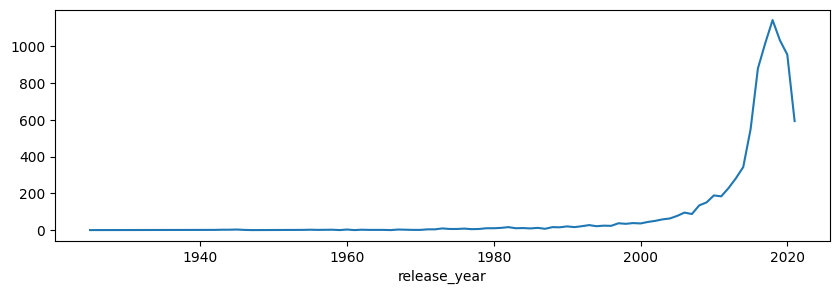

```python
df['release_year'].value_counts().sort_index().plot(figsize=(10,3))
plt.show()
```

```python
movies=df[df['type']=='Movie']
shows=df[df['type']=='TV Show']
```

```python
movies['duration'].head()
```

```
0      90 min
6      91 min
7     125 min
9     104 min
12    127 min
Name: duration, dtype: str
```

```python
shows['duration'].head()
```

```
1    2 Seasons
2     1 Season
3     1 Season
4    2 Seasons
5     1 Season
Name: duration, dtype: str
```

### Data Normalization:

- EDA revealed that the listed_in, cast, director, and country columns contain multiple values within a single record. To eliminate redundancy and achieve database normalization, these attributes were separated into individual dimension tables (Genres, Actors, Directors, Countries) and linked to the Content table through bridge tables (Content_Genres, Content_Actors, Content_Directors, and Content_Countries). This design supports many-to-many relationships and improves data integrity.

```python
content = df[
    [
        'show_id',
        'type',
        'title',
        'date_added',
        'release_year',
        'rating',
        'duration',
        'description'
    ]
].copy()

content.rename(
    columns={'show_id':'content_id'},
    inplace=True
)

content.head()
```

|  | content_id | type | title | date_added | release_year | rating | duration | description |
| --- | --- | --- | --- | --- | --- | --- | --- | --- |
| 0 | s1 | Movie | Dick Johnson Is Dead | 25-09-2021 | 2020 | PG-13 | 90 min | As her father nears the end of his life, filmm... |
| 1 | s2 | TV Show | Blood & Water | 24-09-2021 | 2021 | TV-MA | 2 Seasons | After crossing paths at a party, a Cape Town t... |
| 2 | s3 | TV Show | Ganglands | 24-09-2021 | 2021 | TV-MA | 1 Season | To protect his family from a powerful drug lor... |
| 3 | s4 | TV Show | Jailbirds New Orleans | 24-09-2021 | 2021 | TV-MA | 1 Season | Feuds, flirtations and toilet talk go down amo... |
| 4 | s5 | TV Show | Kota Factory | 24-09-2021 | 2021 | TV-MA | 2 Seasons | In a city of coaching centers known to train I... |

```python
content['date_added'] = pd.to_datetime(
    content['date_added'],
    format='%d-%m-%Y'
)
```

```python
content['date_added'] = content['date_added'].dt.strftime('%Y-%m-%d')
```

```python
content.head()
```

|  | content_id | type | title | date_added | release_year | rating | duration | description |
| --- | --- | --- | --- | --- | --- | --- | --- | --- |
| 0 | s1 | Movie | Dick Johnson Is Dead | 2021-09-25 | 2020 | PG-13 | 90 min | As her father nears the end of his life, filmm... |
| 1 | s2 | TV Show | Blood & Water | 2021-09-24 | 2021 | TV-MA | 2 Seasons | After crossing paths at a party, a Cape Town t... |
| 2 | s3 | TV Show | Ganglands | 2021-09-24 | 2021 | TV-MA | 1 Season | To protect his family from a powerful drug lor... |
| 3 | s4 | TV Show | Jailbirds New Orleans | 2021-09-24 | 2021 | TV-MA | 1 Season | Feuds, flirtations and toilet talk go down amo... |
| 4 | s5 | TV Show | Kota Factory | 2021-09-24 | 2021 | TV-MA | 2 Seasons | In a city of coaching centers known to train I... |

```python
content.shape
```

```
(8706, 8)
```

```python
genres = set()

for item in df['listed_in']:

    for genre in item.split(','):

        genres.add(genre.strip())

genres_df = pd.DataFrame(
    sorted(genres),
    columns=['genre_name']
)

genres_df['genre_id'] = range(
    1,
    len(genres_df)+1
)

genres_df = genres_df[
    ['genre_id','genre_name']
]

genres_df.head()
```

|  | genre_id | genre_name |
| --- | --- | --- |
| 0 | 1 | Action & Adventure |
| 1 | 2 | Anime Features |
| 2 | 3 | Anime Series |
| 3 | 4 | British TV Shows |
| 4 | 5 | Children & Family Movies |

```python
genres_df.shape
```

```
(42, 2)
```

```python
rows = []

for _, row in df.iterrows():

    content_id = row['show_id']

    genres = row['listed_in'].split(',')

    for genre in genres:

        genre = genre.strip()

        genre_id = genres_df.loc[
            genres_df['genre_name']==genre,
            'genre_id'
        ].iloc[0]

        rows.append(
            [content_id, genre_id]
        )

content_genres = pd.DataFrame(
    rows,
    columns=[
        'content_id',
        'genre_id'
    ]
)

content_genres.head()
```

|  | content_id | genre_id |
| --- | --- | --- |
| 0 | s1 | 11 |
| 1 | s2 | 18 |
| 2 | s2 | 35 |
| 3 | s2 | 37 |
| 4 | s3 | 9 |

```python
content_genres.shape
```

```
(19117, 2)
```

```python
content_genres.duplicated().sum()
```

```
np.int64(0)
```

```python
content.isnull().sum()
```

```
content_id      0
type            0
title           0
date_added      0
release_year    0
rating          0
duration        0
description     0
dtype: int64
```

```python
genres_df.isnull().sum()
```

```
genre_id      0
genre_name    0
dtype: int64
```

```python
content_genres.isnull().sum()
```

```
content_id    0
genre_id      0
dtype: int64
```

```python
directors = set()

for item in df['director'].dropna():

    if item != 'Unknown':

        for director in item.split(','):

            directors.add(director.strip())

directors_df = pd.DataFrame(
    sorted(directors),
    columns=['director_name']
)

directors_df['director_id'] = range(
    1,
    len(directors_df)+1
)

directors_df = directors_df[
    ['director_id','director_name']
]

directors_df.head()
```

|  | director_id | director_name |
| --- | --- | --- |
| 0 | 1 | A. L. Vijay |
| 1 | 2 | A. Raajdheep |
| 2 | 3 | A. Salaam |
| 3 | 4 | A.R. Murugadoss |
| 4 | 5 | Aadish Keluskar |

```python
rows = []

for _, row in df.iterrows():

    if row['director'] != 'Unknown':

        directors = row['director'].split(',')

        for director in directors:

            director = director.strip()

            director_id = directors_df.loc[
                directors_df['director_name']==director,
                'director_id'
            ].iloc[0]

            rows.append(
                [row['show_id'], director_id]
            )

content_directors = pd.DataFrame(
    rows,
    columns=[
        'content_id',
        'director_id'
    ]
)

content_directors.head()
```

|  | content_id | director_id |
| --- | --- | --- |
| 0 | s1 | 2531 |
| 1 | s3 | 2321 |
| 2 | s6 | 3160 |
| 3 | s7 | 3913 |
| 4 | s7 | 2288 |

```python
actors = set()

for item in df['cast'].dropna():

    if item != 'Unknown':

        for actor in item.split(','):

            actors.add(actor.strip())

actors_df = pd.DataFrame(
    sorted(actors),
    columns=['actor_name']
)

actors_df['actor_id'] = range(
    1,
    len(actors_df)+1
)

actors_df = actors_df[
    ['actor_id','actor_name']
]

actors_df.head()
```

|  | actor_id | actor_name |
| --- | --- | --- |
| 0 | 1 | "Riley" Lakdhar Dridi |
| 1 | 2 | 'Najite Dede |
| 2 | 3 | 2 Chainz |
| 3 | 4 | 2Mex |
| 4 | 5 | 4Minute |

```python
actors_df.shape
```

```
(36141, 2)
```

```python
actor_dict = dict(
    zip(
        actors_df['actor_name'],
        actors_df['actor_id']
    )
)
```

```python
rows = []

for _, row in df.iterrows():

    if row['cast'] != 'Unknown':

        actors = row['cast'].split(',')

        for actor in actors:

            actor = actor.strip()

            actor_id = actor_dict[actor]

            rows.append(
                [row['show_id'], actor_id]
            )

content_actors = pd.DataFrame(
    rows,
    columns=[
        'content_id',
        'actor_id'
    ]
)
```

```python
content_actors.head()
```

|  | content_id | actor_id |
| --- | --- | --- |
| 0 | s2 | 1588 |
| 1 | s2 | 17957 |
| 2 | s2 | 10996 |
| 3 | s2 | 32801 |
| 4 | s2 | 8570 |

```python
countries = set()

for item in df['country'].dropna():

    if item != 'Unknown':

        for country in item.split(','):

            countries.add(country.strip())

countries_df = pd.DataFrame(
    sorted(countries),
    columns=['country_name']
)

countries_df['country_id'] = range(
    1,
    len(countries_df)+1
)

countries_df = countries_df[
    ['country_id','country_name']
]

countries_df.head()
```

|  | country_id | country_name |
| --- | --- | --- |
| 0 | 1 |  |
| 1 | 2 | Afghanistan |
| 2 | 3 | Albania |
| 3 | 4 | Algeria |
| 4 | 5 | Angola |

```python
rows = []

for _, row in df.iterrows():

    if row['country'] != 'Unknown':

        countries = row['country'].split(',')

        for country in countries:

            country = country.strip()

            country_id = countries_df.loc[
                countries_df['country_name']==country,
                'country_id'
            ].iloc[0]

            rows.append(
                [row['show_id'], country_id]
            )

content_countries = pd.DataFrame(
    rows,
    columns=[
        'content_id',
        'country_id'
    ]
)

content_countries.head()
```

|  | content_id | country_id |
| --- | --- | --- |
| 0 | s1 | 117 |
| 1 | s2 | 101 |
| 2 | s5 | 47 |
| 3 | s8 | 117 |
| 4 | s8 | 41 |

```python
print(content.shape)

print(genres_df.shape)
print(content_genres.shape)

print(directors_df.shape)
print(content_directors.shape)

print(actors_df.shape)
print(content_actors.shape)

print(countries_df.shape)
print(content_countries.shape)
```

```
(8706, 8)
(42, 2)
(19117, 2)
(4988, 2)
(6969, 2)
(36141, 2)
(63441, 2)
(123, 2)
(9909, 2)
```

### Saving the Dataframes as CSV Files

```python
path = r"C:/Users/Admin/Downloads/archive"

content.to_csv(f"{path}/content.csv", index=False)

genres_df.to_csv(f"{path}/genres.csv", index=False)
content_genres.to_csv(f"{path}/content_genres.csv", index=False)

directors_df.to_csv(f"{path}/directors.csv", index=False)
content_directors.to_csv(f"{path}/content_directors.csv", index=False)

actors_df.to_csv(f"{path}/actors.csv", index=False)
content_actors.to_csv(f"{path}/content_actors.csv", index=False)

countries_df.to_csv(f"{path}/countries.csv", index=False)
content_countries.to_csv(f"{path}/content_countries.csv", index=False)
```

```python
print("Content:", content.shape)

print("Genres:", genres_df.shape)
print("Content_Genres:", content_genres.shape)

print("Directors:", directors_df.shape)
print("Content_Directors:", content_directors.shape)

print("Actors:", actors_df.shape)
print("Content_Actors:", content_actors.shape)

print("Countries:", countries_df.shape)
print("Content_Countries:", content_countries.shape)
```

```
Content: (8706, 8)
Genres: (42, 2)
Content_Genres: (19117, 2)
Directors: (4988, 2)
Content_Directors: (6969, 2)
Actors: (36141, 2)
Content_Actors: (63441, 2)
Countries: (123, 2)
Content_Countries: (9909, 2)
```

### Conclusion of Data Cleaning, EDA, and Normalization

The Netflix OTT dataset was successfully cleaned and prepared for database design. Missing values, duplicate records, and data quality issues were identified and handled appropriately. Exploratory Data Analysis (EDA) was performed to understand the dataset structure, content distribution, genre patterns, country information, director details, and cast information.

The analysis revealed that several columns such as listed_in, cast, director, and country contained multiple values within a single field, leading to data redundancy and making analysis difficult. To address this issue, the dataset was normalized by separating these multi-valued attributes into individual dimension tables and creating bridge tables to maintain many-to-many relationships.

This normalized schema reduces redundancy, improves data integrity, and enables efficient querying and analysis. With the data preparation phase completed, the next step is to design and implement the relational database in MySQL by creating databases, tables, primary keys, and foreign key relationships.

### Database Design and Implementation

**Objective:**

To create a relational database for the OTT Analytics platform by implementing the normalized schema using MySQL. The database will establish relationships between content, genres, actors, directors, and countries through primary and foreign key constraints to ensure data integrity and support advanced analytical queries.

```python
import mysql.connector

conn = mysql.connector.connect(
    host='localhost',
    user='root',
    password='root'
)

cursor = conn.cursor()

print("Connected Successfully")
```

```
Connected Successfully
```

```python
cursor.execute("""
CREATE DATABASE IF NOT EXISTS ott_analytics;
""")

print("Database Created")
```

```
Database Created
```

```python
cursor.execute('''
USE ott_analytics''')
```

```python
cursor.execute("""
CREATE TABLE content (
    content_id VARCHAR(10) PRIMARY KEY,
    type VARCHAR(20),
    title VARCHAR(300),
    date_added DATE,
    release_year INT,
    rating VARCHAR(20),
    duration VARCHAR(30),
    description TEXT
);
""")
```

```python
cursor.execute("""
CREATE TABLE genres (
    genre_id INT PRIMARY KEY,
    genre_name VARCHAR(100)
);
""")
```

```python
cursor.execute("""
CREATE TABLE content_genres (
    content_id VARCHAR(10),
    genre_id INT,

    PRIMARY KEY(content_id, genre_id),

    FOREIGN KEY(content_id) REFERENCES content(content_id),

    FOREIGN KEY(genre_id) REFERENCES genres(genre_id)
);
""")
```

```python
cursor.execute("""
CREATE TABLE directors (
    director_id INT PRIMARY KEY,
    director_name VARCHAR(255)
);
""")
```

```python
cursor.execute("""
CREATE TABLE content_directors (
    content_id VARCHAR(10),
    director_id INT,

    PRIMARY KEY(content_id, director_id),

    FOREIGN KEY(content_id) REFERENCES content(content_id),

    FOREIGN KEY(director_id) REFERENCES directors(director_id)
);
""")
```

```python
cursor.execute('''
CREATE TABLE actors(
    actor_id INT PRIMARY KEY,
    actor_name VARCHAR(255)
    );
''')
```

```python
cursor.execute("""
CREATE TABLE content_actors(
    content_id VARCHAR(20),
    actor_id INT,

    PRIMARY KEY(content_id,actor_id),

    FOREIGN KEY(content_id) REFERENCES content(content_id),

    FOREIGN KEY(actor_id) REFERENCES actors(actor_id)
);
""")
```

```python
cursor.execute("""
CREATE TABLE countries(
    country_id INT PRIMARY KEY,
    country_name VARCHAR(100)
);
""")
```

```python
cursor.execute("""
CREATE TABLE content_countries (
    content_id VARCHAR(10),
    country_id INT,

    PRIMARY KEY(content_id, country_id),

    FOREIGN KEY(content_id) REFERENCES content(content_id),

    FOREIGN KEY(country_id) REFERENCES countries(country_id)
);
""")
```

```python
cursor.execute("SHOW tables")
for i in cursor:
    print(i)
```

```
('actors',)
('content',)
('content_actors',)
('content_countries',)
('content_directors',)
('content_genres',)
('countries',)
('directors',)
('genres',)
```

```python
content.info()
```

```
<class 'pandas.DataFrame'>
RangeIndex: 8706 entries, 0 to 8705
Data columns (total 8 columns):
 #   Column        Non-Null Count  Dtype
---  ------        --------------  -----
 0   content_id    8706 non-null   str
 1   type          8706 non-null   str
 2   title         8706 non-null   str
 3   date_added    8706 non-null   str
 4   release_year  8706 non-null   int64
 5   rating        8706 non-null   str
 6   duration      8706 non-null   str
 7   description   8706 non-null   str
dtypes: int64(1), str(7)
memory usage: 544.3 KB
```

```python
content.head()
```

|  | content_id | type | title | date_added | release_year | rating | duration | description |
| --- | --- | --- | --- | --- | --- | --- | --- | --- |
| 0 | s1 | Movie | Dick Johnson Is Dead | 2021-09-25 | 2020 | PG-13 | 90 min | As her father nears the end of his life, filmm... |
| 1 | s2 | TV Show | Blood & Water | 2021-09-24 | 2021 | TV-MA | 2 Seasons | After crossing paths at a party, a Cape Town t... |
| 2 | s3 | TV Show | Ganglands | 2021-09-24 | 2021 | TV-MA | 1 Season | To protect his family from a powerful drug lor... |
| 3 | s4 | TV Show | Jailbirds New Orleans | 2021-09-24 | 2021 | TV-MA | 1 Season | Feuds, flirtations and toilet talk go down amo... |
| 4 | s5 | TV Show | Kota Factory | 2021-09-24 | 2021 | TV-MA | 2 Seasons | In a city of coaching centers known to train I... |

```python
content.shape
```

```
(8706, 8)
```

```python
import pandas as pd

test = pd.read_csv(r"C:/Users/Admin/Downloads/archive/content.csv")

print(test.shape)
```

```
(8706, 8)
```

```python
directors_df.to_sql(
    "directors",
    con=engine,
    if_exists="append",
    index=False
)
```

```
4988
```

```python
actors_df.to_sql("actors", con=engine, if_exists="append", index=False)
```

```
36141
```

```python
countries_df.to_sql("countries", con=engine, if_exists="append", index=False)
```

```
123
```

```python
content_genres.to_sql("content_genres", con=engine, if_exists="append", index=False)
```

```
19117
```

```python
content_directors.to_sql("content_directors", con=engine, if_exists="append", index=False)
```

```
6968
```

```python
content_countries.to_sql("content_countries", con=engine, if_exists="append", index=False)
```

```
9909
```

```python
content_actors.to_sql("content_actors", con=engine, if_exists="append", index=False)
```

```
63439
```

```python
import warnings
warnings.filterwarnings('ignore')
```

### Queries

#### 1) Total Content

```python
q1 = """
SELECT COUNT(*) AS total_titles
FROM content;
"""
df_q1 = pd.read_sql(q1, conn)
df_q1
```

|  | total_titles |
| --- | --- |
| 0 | 8706 |

#### 2) Movies vs TV Shows

```python
q2 = """
SELECT type,
       COUNT(*) AS total_titles
FROM content
GROUP BY type;
"""

df_q2 = pd.read_sql(q2, conn)
df_q2
```

|  | type | total_titles |
| --- | --- | --- |
| 0 | Movie | 6128 |
| 1 | TV Show | 2578 |

#### 3) Content Rating

```python
q3 = """
SELECT rating,
       COUNT(*) AS total_titles
FROM content
GROUP BY rating
ORDER BY total_titles DESC;
"""

df_q3 = pd.read_sql(q3, conn)
df_q3
```

|  | rating | total_titles |
| --- | --- | --- |
| 0 | TV-MA | 3187 |
| 1 | TV-14 | 2133 |
| 2 | TV-PG | 838 |
| 3 | R | 799 |
| 4 | PG-13 | 490 |
| 5 | TV-Y7 | 330 |
| 6 | TV-Y | 300 |
| 7 | PG | 287 |
| 8 | TV-G | 212 |
| 9 | NR | 78 |
| 10 | G | 41 |
| 11 | TV-Y7-FV | 5 |
| 12 | NC-17 | 3 |
| 13 | UR | 3 |

#### 4) Content Added per year

```python
q4 = """
SELECT YEAR(date_added) AS year_added,
       COUNT(*) AS total_titles
FROM content
GROUP BY YEAR(date_added)
ORDER BY year_added;
"""

df_q4 = pd.read_sql(q4, conn)
df_q4
```

|  | year_added | total_titles |
| --- | --- | --- |
| 0 | 2008 | 2 |
| 1 | 2009 | 2 |
| 2 | 2010 | 1 |
| 3 | 2011 | 13 |
| 4 | 2012 | 3 |
| 5 | 2013 | 10 |
| 6 | 2014 | 23 |
| 7 | 2015 | 73 |
| 8 | 2016 | 416 |
| 9 | 2017 | 1163 |
| 10 | 2018 | 1625 |
| 11 | 2019 | 1999 |
| 12 | 2020 | 1878 |
| 13 | 2021 | 1498 |

#### 5) Top Release Years

```python
q5 = """
SELECT release_year,
       COUNT(*) AS total_titles
FROM content
GROUP BY release_year
ORDER BY total_titles DESC
LIMIT 10;
"""

df_q5 = pd.read_sql(q5, conn)
df_q5
```

|  | release_year | total_titles |
| --- | --- | --- |
| 0 | 2018 | 1140 |
| 1 | 2019 | 1030 |
| 2 | 2017 | 1015 |
| 3 | 2020 | 953 |
| 4 | 2016 | 878 |
| 5 | 2021 | 592 |
| 6 | 2015 | 548 |
| 7 | 2014 | 343 |
| 8 | 2013 | 282 |
| 9 | 2012 | 229 |

#### 6) Top Genres

```python
q6 = """
SELECT g.genre_name,
       COUNT(*) AS total_titles
FROM genres g
JOIN content_genres cg
ON g.genre_id = cg.genre_id
GROUP BY g.genre_name
ORDER BY total_titles DESC
LIMIT 10;
"""

df_q6 = pd.read_sql(q6, conn)
df_q6
```

|  | genre_name | total_titles |
| --- | --- | --- |
| 0 | International Movies | 2752 |
| 1 | Dramas | 2427 |
| 2 | Comedies | 1674 |
| 3 | International TV Shows | 1328 |
| 4 | Documentaries | 869 |
| 5 | Action & Adventure | 859 |
| 6 | Independent Movies | 756 |
| 7 | TV Dramas | 739 |
| 8 | Children & Family Movies | 641 |
| 9 | Romantic Movies | 616 |

#### 7) Top Countries

```python
q7 = """
SELECT co.country_name,
       COUNT(*) AS total_titles
FROM countries co
JOIN content_countries cc
ON co.country_id = cc.country_id
GROUP BY co.country_name
ORDER BY total_titles DESC
LIMIT 10;
"""

df_q7 = pd.read_sql(q7, conn)
df_q7
```

|  | country_name | total_titles |
| --- | --- | --- |
| 0 | United States | 3640 |
| 1 | India | 1045 |
| 2 | United Kingdom | 787 |
| 3 | Canada | 432 |
| 4 | France | 389 |
| 5 | Japan | 314 |
| 6 | Spain | 228 |
| 7 | South Korea | 226 |
| 8 | Germany | 225 |
| 9 | Mexico | 169 |

#### 8) Top directors

```python
q8 = """
SELECT d.director_name,
       COUNT(*) AS total_titles
FROM directors d
JOIN content_directors cd
ON d.director_id = cd.director_id
GROUP BY d.director_name
ORDER BY total_titles DESC
LIMIT 10;
"""

df_q8 = pd.read_sql(q8, conn)
df_q8
```

|  | director_name | total_titles |
| --- | --- | --- |
| 0 | Rajiv Chilaka | 22 |
| 1 | Jan Suter | 21 |
| 2 | Raúl Campos | 19 |
| 3 | Marcus Raboy | 16 |
| 4 | Suhas Kadav | 16 |
| 5 | Jay Karas | 15 |
| 6 | Cathy Garcia-Molina | 13 |
| 7 | Jay Chapman | 12 |
| 8 | Martin Scorsese | 12 |
| 9 | Youssef Chahine | 12 |

#### 9) Top Actors

```python
q9 = """
SELECT a.actor_name,
       COUNT(*) AS total_titles
FROM actors a
JOIN content_actors ca
ON a.actor_id = ca.actor_id
GROUP BY a.actor_name
ORDER BY total_titles DESC
LIMIT 10;
"""

df_q9 = pd.read_sql(q9, conn)
df_q9
```

|  | actor_name | total_titles |
| --- | --- | --- |
| 0 | Anupam Kher | 43 |
| 1 | Shah Rukh Khan | 35 |
| 2 | Julie Tejwani | 33 |
| 3 | Naseeruddin Shah | 32 |
| 4 | Takahiro Sakurai | 31 |
| 5 | Rupa Bhimani | 31 |
| 6 | Akshay Kumar | 30 |
| 7 | Om Puri | 30 |
| 8 | Yuki Kaji | 29 |
| 9 | Paresh Rawal | 28 |

#### 10) Top Movie genres

```python
q10 = """
SELECT g.genre_name,
       COUNT(*) AS movie_count
FROM genres g
JOIN content_genres cg
ON g.genre_id = cg.genre_id
JOIN content c
ON cg.content_id = c.content_id
WHERE c.type='Movie'
GROUP BY g.genre_name
ORDER BY movie_count DESC;
"""

df_q10 = pd.read_sql(q10, conn)
df_q10
```

|  | genre_name | movie_count |
| --- | --- | --- |
| 0 | International Movies | 2752 |
| 1 | Dramas | 2427 |
| 2 | Comedies | 1674 |
| 3 | Documentaries | 869 |
| 4 | Action & Adventure | 859 |
| 5 | Independent Movies | 756 |
| 6 | Children & Family Movies | 641 |
| 7 | Romantic Movies | 616 |
| 8 | Thrillers | 577 |
| 9 | Music & Musicals | 375 |
| 10 | Horror Movies | 357 |
| 11 | Stand-Up Comedy | 343 |
| 12 | Sci-Fi & Fantasy | 243 |
| 13 | Sports Movies | 219 |
| 14 | Classic Movies | 116 |
| 15 | LGBTQ Movies | 102 |
| 16 | Anime Features | 71 |
| 17 | Cult Movies | 71 |
| 18 | Faith & Spirituality | 65 |
| 19 | Movies | 54 |

#### 11) Top TV Show Genres

```python
q11 = """
SELECT g.genre_name,
       COUNT(*) AS tvshow_count
FROM genres g
JOIN content_genres cg
ON g.genre_id = cg.genre_id
JOIN content c
ON cg.content_id = c.content_id
WHERE c.type='TV Show'
GROUP BY g.genre_name
ORDER BY tvshow_count DESC;
"""

df_q11 = pd.read_sql(q11, conn)
df_q11
```

|  | genre_name | tvshow_count |
| --- | --- | --- |
| 0 | International TV Shows | 1328 |
| 1 | TV Dramas | 739 |
| 2 | TV Comedies | 550 |
| 3 | Crime TV Shows | 459 |
| 4 | Kids' TV | 433 |
| 5 | Docuseries | 380 |
| 6 | Romantic TV Shows | 364 |
| 7 | Reality TV | 244 |
| 8 | British TV Shows | 235 |
| 9 | Anime Series | 172 |
| 10 | Spanish-Language TV Shows | 168 |
| 11 | TV Action & Adventure | 160 |
| 12 | Korean TV Shows | 147 |
| 13 | TV Mysteries | 95 |
| 14 | Science & Nature TV | 87 |
| 15 | TV Sci-Fi & Fantasy | 82 |
| 16 | TV Horror | 72 |
| 17 | Teen TV Shows | 68 |
| 18 | TV Thrillers | 56 |
| 19 | Stand-Up Comedy & Talk Shows | 54 |
| 20 | Classic & Cult TV | 21 |
| 21 | TV Shows | 16 |

#### 12) Country Producing with most Movies

```python
q12 = """
SELECT co.country_name,
       COUNT(*) AS movie_count
FROM countries co
JOIN content_countries cc
ON co.country_id = cc.country_id
JOIN content c
ON cc.content_id = c.content_id
WHERE c.type='Movie'
GROUP BY co.country_name
ORDER BY movie_count DESC
LIMIT 10;
"""

df_q12 = pd.read_sql(q12, conn)
df_q12
```

|  | country_name | movie_count |
| --- | --- | --- |
| 0 | United States | 2749 |
| 1 | India | 962 |
| 2 | United Kingdom | 534 |
| 3 | Canada | 319 |
| 4 | France | 303 |
| 5 | Germany | 182 |
| 6 | Spain | 171 |
| 7 | Japan | 119 |
| 8 | China | 114 |
| 9 | Mexico | 111 |

#### 13) Country Producing with most Tv Shows

```python
q13 = """
SELECT co.country_name,
       COUNT(*) AS tv_count
FROM countries co
JOIN content_countries cc
ON co.country_id = cc.country_id
JOIN content c
ON cc.content_id = c.content_id
WHERE c.type='TV Show'
GROUP BY co.country_name
ORDER BY tv_count DESC
LIMIT 10;
"""

df_q13 = pd.read_sql(q13, conn)
df_q13
```

|  | country_name | tv_count |
| --- | --- | --- |
| 0 | United States | 891 |
| 1 | United Kingdom | 253 |
| 2 | Japan | 195 |
| 3 | South Korea | 165 |
| 4 | Canada | 113 |
| 5 | France | 86 |
| 6 | India | 83 |
| 7 | Taiwan | 70 |
| 8 | Australia | 63 |
| 9 | Mexico | 58 |

#### 14) Movie Rating Distributions

```python
q14 = """
SELECT rating,
       COUNT(*) AS movie_count
FROM content
WHERE type='Movie'
GROUP BY rating
ORDER BY movie_count DESC;
"""

df_q14 = pd.read_sql(q14, conn)
df_q14
```

|  | rating | movie_count |
| --- | --- | --- |
| 0 | TV-MA | 2064 |
| 1 | TV-14 | 1427 |
| 2 | R | 797 |
| 3 | TV-PG | 540 |
| 4 | PG-13 | 490 |
| 5 | PG | 287 |
| 6 | TV-Y7 | 139 |
| 7 | TV-Y | 131 |
| 8 | TV-G | 126 |
| 9 | NR | 75 |
| 10 | G | 41 |
| 11 | TV-Y7-FV | 5 |
| 12 | NC-17 | 3 |
| 13 | UR | 3 |

#### 15) TV Show Rating Distributions

```python
q15 = """
SELECT rating,
       COUNT(*) AS tv_count
FROM content
WHERE type='TV Show'
GROUP BY rating
ORDER BY tv_count DESC;
"""

df_q15 = pd.read_sql(q15, conn)
df_q15
```

|  | rating | tv_count |
| --- | --- | --- |
| 0 | TV-MA | 1123 |
| 1 | TV-14 | 706 |
| 2 | TV-PG | 298 |
| 3 | TV-Y7 | 191 |
| 4 | TV-Y | 169 |
| 5 | TV-G | 86 |
| 6 | NR | 3 |
| 7 | R | 2 |

#### 16) Genres Above Average Popularity

```python
q16 = """
WITH genre_count AS
(
    SELECT g.genre_name,
           COUNT(*) AS total_titles
    FROM genres g
    JOIN content_genres cg
    ON g.genre_id=cg.genre_id
    GROUP BY g.genre_name
)
SELECT *
FROM genre_count
WHERE total_titles >
(
    SELECT AVG(total_titles)
    FROM genre_count
);
"""

df_q16 = pd.read_sql(q16, conn)
df_q16
```

|  | genre_name | total_titles |
| --- | --- | --- |
| 0 | Action & Adventure | 859 |
| 1 | Children & Family Movies | 641 |
| 2 | Comedies | 1674 |
| 3 | Crime TV Shows | 459 |
| 4 | Documentaries | 869 |
| 5 | Dramas | 2427 |
| 6 | Independent Movies | 756 |
| 7 | International Movies | 2752 |
| 8 | International TV Shows | 1328 |
| 9 | Romantic Movies | 616 |
| 10 | TV Comedies | 550 |
| 11 | TV Dramas | 739 |
| 12 | Thrillers | 577 |

#### 17) Directors Above Average Productivity

```python
q17 = """
WITH director_count AS
(
    SELECT c.director_id, d.director_name, COUNT(*) AS total_titles
    FROM content_directors c
    JOIN directors d
    ON c.director_id=d.director_id
    GROUP BY c.director_id
)
SELECT *
FROM director_count
WHERE total_titles >
(
    SELECT AVG(total_titles)
    FROM director_count
);
"""

df_q17 = pd.read_sql(q17, conn)
df_q17
```

|  | director_id | director_name | total_titles |
| --- | --- | --- | --- |
| 0 | 1 | A. L. Vijay | 2 |
| 1 | 4 | A.R. Murugadoss | 2 |
| 2 | 13 | Aaron Moorhead | 2 |
| 3 | 15 | Aaron Sorkin | 2 |
| 4 | 19 | Abba T. Makama | 2 |
| ... | ... | ... | ... |
| 1014 | 4970 | Zoya Akhtar | 6 |
| 1015 | 4974 | Àlex Pastor | 2 |
| 1016 | 4975 | Álex de la Iglesia | 2 |
| 1017 | 4987 | Ömer Faruk Sorak | 3 |
| 1018 | 4988 | Şenol Sönmez | 2 |

1019 rows × 3 columns

#### 18) Ranking Genres

```python
q18 = """
SELECT genre_name,
       total_titles,
       RANK() OVER(ORDER BY total_titles DESC) AS genre_rank
FROM
(
    SELECT g.genre_name,
           COUNT(*) AS total_titles
    FROM genres g
    JOIN content_genres cg
    ON g.genre_id=cg.genre_id
    GROUP BY g.genre_name
) x;
"""

df_q18 = pd.read_sql(q18, conn)
df_q18
```

|  | genre_name | total_titles | genre_rank |
| --- | --- | --- | --- |
| 0 | International Movies | 2752 | 1 |
| 1 | Dramas | 2427 | 2 |
| 2 | Comedies | 1674 | 3 |
| 3 | International TV Shows | 1328 | 4 |
| 4 | Documentaries | 869 | 5 |
| 5 | Action & Adventure | 859 | 6 |
| 6 | Independent Movies | 756 | 7 |
| 7 | TV Dramas | 739 | 8 |
| 8 | Children & Family Movies | 641 | 9 |
| 9 | Romantic Movies | 616 | 10 |
| 10 | Thrillers | 577 | 11 |
| 11 | TV Comedies | 550 | 12 |
| 12 | Crime TV Shows | 459 | 13 |
| 13 | Kids' TV | 433 | 14 |
| 14 | Docuseries | 380 | 15 |
| 15 | Music & Musicals | 375 | 16 |
| 16 | Romantic TV Shows | 364 | 17 |
| 17 | Horror Movies | 357 | 18 |
| 18 | Stand-Up Comedy | 343 | 19 |
| 19 | Reality TV | 244 | 20 |
| 20 | Sci-Fi & Fantasy | 243 | 21 |
| 21 | British TV Shows | 235 | 22 |
| 22 | Sports Movies | 219 | 23 |
| 23 | Anime Series | 172 | 24 |
| 24 | Spanish-Language TV Shows | 168 | 25 |
| 25 | TV Action & Adventure | 160 | 26 |
| 26 | Korean TV Shows | 147 | 27 |
| 27 | Classic Movies | 116 | 28 |
| 28 | LGBTQ Movies | 102 | 29 |
| 29 | TV Mysteries | 95 | 30 |
| 30 | Science & Nature TV | 87 | 31 |
| 31 | TV Sci-Fi & Fantasy | 82 | 32 |
| 32 | TV Horror | 72 | 33 |
| 33 | Anime Features | 71 | 34 |
| 34 | Cult Movies | 71 | 34 |
| 35 | Teen TV Shows | 68 | 36 |
| 36 | Faith & Spirituality | 65 | 37 |
| 37 | TV Thrillers | 56 | 38 |
| 38 | Movies | 54 | 39 |
| 39 | Stand-Up Comedy & Talk Shows | 54 | 39 |
| 40 | Classic & Cult TV | 21 | 41 |
| 41 | TV Shows | 16 | 42 |

#### 19) Ranking Countries

```python
q19 = """
SELECT country_name,
       total_titles,
       DENSE_RANK() OVER(ORDER BY total_titles DESC) AS country_rank
FROM
(
    SELECT co.country_name,
           COUNT(*) AS total_titles
    FROM countries co
    JOIN content_countries cc
    ON co.country_id=cc.country_id
    GROUP BY co.country_name
) x;
"""

df_q19 = pd.read_sql(q19, conn)
df_q19
```

|  | country_name | total_titles | country_rank |
| --- | --- | --- | --- |
| 0 | United States | 3640 | 1 |
| 1 | India | 1045 | 2 |
| 2 | United Kingdom | 787 | 3 |
| 3 | Canada | 432 | 4 |
| 4 | France | 389 | 5 |
| ... | ... | ... | ... |
| 118 | Somalia | 1 | 55 |
| 119 | Sri Lanka | 1 | 55 |
| 120 | Sudan | 1 | 55 |
| 121 | Uganda | 1 | 55 |
| 122 | Vatican City | 1 | 55 |

123 rows × 3 columns

#### 20) Running Total of Content Growth

```python
q20 = """
SELECT release_year,
       yearly_titles,
       SUM(yearly_titles)
       OVER(ORDER BY release_year) AS cumulative_titles
FROM
(
    SELECT release_year,
           COUNT(*) AS yearly_titles
    FROM content
    GROUP BY release_year
) x;
"""

df_q20 = pd.read_sql(q20, conn)
df_q20
```

|  | release_year | yearly_titles | cumulative_titles |
| --- | --- | --- | --- |
| 0 | 1925 | 1 | 1.0 |
| 1 | 1942 | 2 | 3.0 |
| 2 | 1943 | 3 | 6.0 |
| 3 | 1944 | 3 | 9.0 |
| 4 | 1945 | 4 | 13.0 |
| ... | ... | ... | ... |
| 69 | 2017 | 1015 | 4991.0 |
| 70 | 2018 | 1140 | 6131.0 |
| 71 | 2019 | 1030 | 7161.0 |
| 72 | 2020 | 953 | 8114.0 |
| 73 | 2021 | 592 | 8706.0 |

74 rows × 3 columns

#### 21) Directors Who Worked Across Multiple Genres

```python
q21='''SELECT d.director_name,
       COUNT(DISTINCT cg.genre_id) AS genre_count
FROM directors d
JOIN content_directors cd
ON d.director_id = cd.director_id
JOIN content_genres cg
ON cd.content_id = cg.content_id
GROUP BY d.director_name
ORDER BY genre_count DESC
LIMIT 10;'''
df_q21 = pd.read_sql(q21, conn)
df_q21
```

|  | director_name | genre_count |
| --- | --- | --- |
| 0 | Anurag Kashyap | 9 |
| 1 | Martin Scorsese | 9 |
| 2 | Vikramaditya Motwane | 8 |
| 3 | Nicolás López | 8 |
| 4 | Abhishek Chaubey | 8 |
| 5 | Vishal Bhardwaj | 8 |
| 6 | Ifa Isfansyah | 8 |
| 7 | Priyadarshan | 8 |
| 8 | BB Sasore | 7 |
| 9 | Jalil Lespert | 7 |

#### 22) Average Number of Actors per Content

```python
q22='''
SELECT ROUND(AVG(actor_count),2) AS avg_actors
FROM
(
    SELECT content_id,
           COUNT(actor_id) AS actor_count
    FROM content_actors
    GROUP BY content_id
) x;'''

df_q22=pd.read_sql(q22,conn)
df_q22
```

|  | avg_actors |
| --- | --- |
| 0 | 8.04 |

The SQL analysis provided valuable insights into the OTT platform's content library by examining content types, genres, countries, directors, actors, ratings, and release trends. Through the use of aggregate functions, joins, subqueries, Common Table Expressions (CTEs), and window functions, meaningful business questions were answered and key patterns were identified.

The analysis revealed the distribution of Movies and TV Shows, the most popular genres, leading content-producing countries, top directors and actors, and the growth of content over time. Window functions helped analyze rankings and cumulative content growth, while CTEs enabled advanced comparisons such as identifying genres and directors performing above average.

Overall, SQL proved to be an effective tool for transforming raw relational data into actionable business insights, supporting data-driven decision-making and strategic content planning for OTT platforms.

### Data Visualization of Queries

```python
import matplotlib.pyplot as plt
```

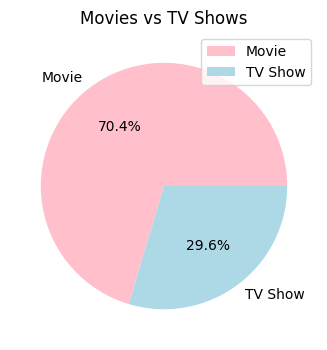

```python
df_q2.plot(
    kind='pie',
    y='total_titles',
    labels=df_q2['type'],
    autopct='%1.1f%%',colors=['pink','lightblue'],
    figsize=(8,4)
)
plt.title("Movies vs TV Shows")
plt.show()
```

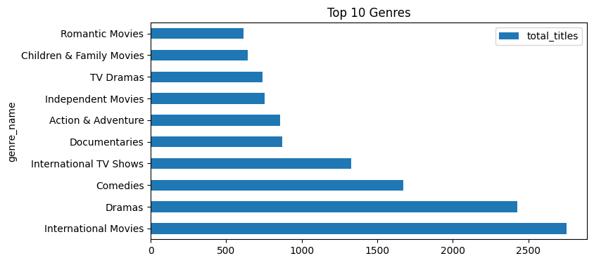

```python
df_q6.plot(
    kind='barh',
    x='genre_name',
    y='total_titles',
    figsize=(8,4)
)

plt.title("Top 10 Genres")
plt.show()
```

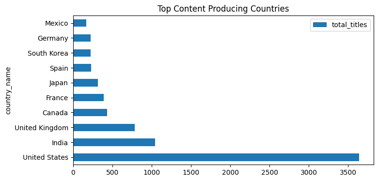

```python
df_q7.plot(
    kind='barh',
    x='country_name',
    y='total_titles',
    figsize=(8,4)
)

plt.title("Top Content Producing Countries")
plt.show()
```

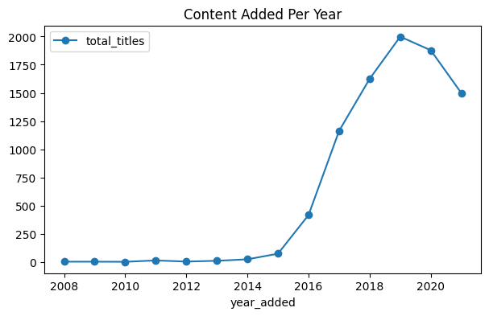

```python
df_q4.plot(
    kind='line',
    x='year_added',
    y='total_titles',
    marker='o',
    figsize=(7,4)
)

plt.title("Content Added Per Year")
plt.show()
```

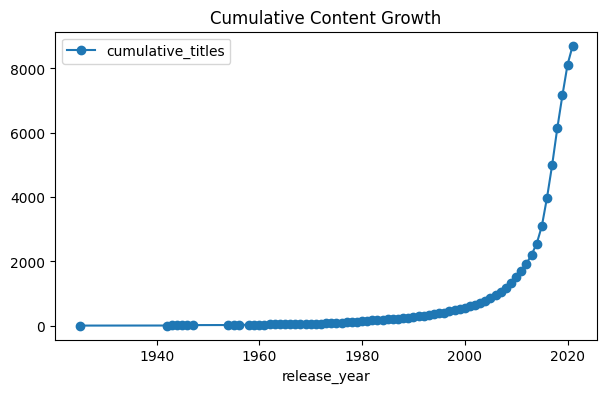

```python
df_q20.plot(
    kind='line',
    x='release_year',
    y='cumulative_titles',
    marker='o',
    figsize=(7,4)
)

plt.title("Cumulative Content Growth")
plt.show()
```

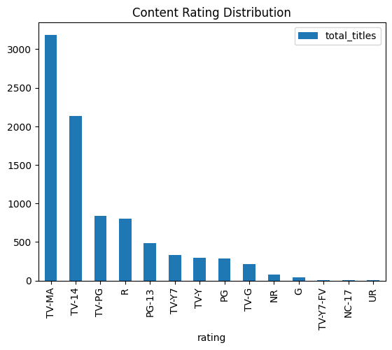

```python
df_q3.plot(
    kind='bar',
    x='rating',
    y='total_titles'
)

plt.title("Content Rating Distribution")
plt.show()
```

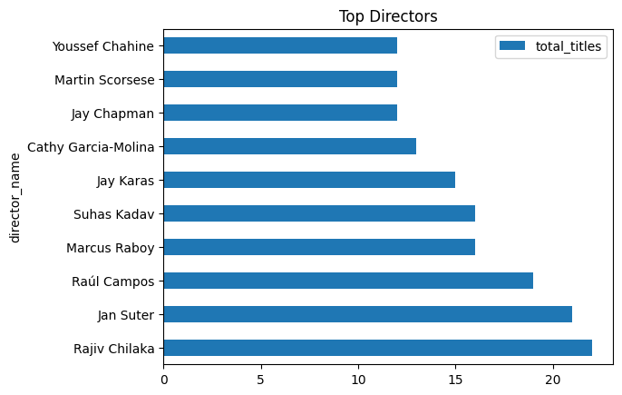

```python
df_q8.plot(
    kind='barh',
    x='director_name',
    y='total_titles'
)

plt.title("Top Directors")
plt.show()
```

The visualizations provided a clear and intuitive understanding of the OTT platform's content distribution and growth patterns. Through charts and graphs, key trends that were difficult to identify from raw data alone became more evident and easier to interpret.

The analysis highlighted the dominance of specific content types, genres, and countries in the platform's catalog. Visualizations also revealed how content availability has evolved over time, demonstrating significant growth in the platform's content library. Genre and country-wise comparisons helped identify the most influential contributors to the platform, while trend analysis offered insights into content expansion and changing content preferences.

By transforming SQL query outputs into visual representations, complex relationships and patterns were communicated more effectively, enabling faster interpretation and better decision-making. Overall, data visualization complemented the SQL analysis by converting analytical findings into actionable business insights and providing a comprehensive view of the OTT platform's content ecosystem.

### Recommendations

- Expand investments in underrepresented genres to attract a wider audience and reduce dependence on a few dominant categories.
- Increase partnerships with content creators from emerging countries to improve regional diversity and strengthen the platform's global presence.
- Analyze viewer engagement alongside content availability to determine whether the most frequent genres and directors also generate the highest audience retention.
- Continue balancing investments between Movies and TV Shows based on audience consumption trends and market demand.
- Introduce personalized recommendation strategies by combining genre, cast, director, and country information to improve the user viewing experience.
- Develop interactive dashboards that monitor content growth, genre performance, regional contributions, and rating distributions in real time to support business decision-making.

### Conclusion:

The OTT Analytics project successfully transformed a raw Netflix dataset into a structured and analysis-ready relational database. The project began with data cleaning and preprocessing, where missing values, inconsistencies, and formatting issues were addressed. Exploratory Data Analysis (EDA) was then performed to understand content distribution, release trends, ratings, genres, countries, directors, and actors.

To eliminate data redundancy and improve data integrity, the dataset was normalized into multiple related tables including Content, Genres, Directors, Actors, Countries, and their corresponding bridge tables. This normalization process enabled efficient storage and supported complex many-to-many relationships within the database.

The normalized datasets were imported into MySQL, where a relational database was designed using primary and foreign key constraints. SQL queries ranging from basic aggregations to advanced joins, Common Table Expressions (CTEs), and window functions were executed to generate meaningful business insights. The analysis revealed trends in content growth, genre popularity, country-wise content production, director contributions, actor participation, and platform content distribution.

Visualizations were created to effectively communicate key findings such as Movies vs TV Shows distribution, top-performing genres, leading content-producing countries, yearly content growth, and cumulative expansion of the content library.

Overall, this project demonstrates the complete data analytics workflow, including data cleaning, exploratory analysis, database design, normalization, SQL-based analysis, and data visualization. The insights generated can help OTT platforms better understand content trends, audience preferences, and strategic content planning decisions.